# Modern Data Mining: PCA

## 3.2 What effect does `time` have on `MPG`?

1. Start with a simple regression of `mpg` vs. `year` and report R’s `summary` output. Is `year` a significant variable at the .05 level? State what effect `year` has on `mpg`, if any, according to this model.

```r
fit1 <- lm(mpg ~ year, data=Auto)
summary(fit1)
```

```
##
## Call:
## lm(formula = mpg ~ year, data = Auto)
##
## Residuals:
##     Min      1Q  Median      3Q     Max
## -12.021  -5.441  -0.441   4.974  18.209
##
## Coefficients:
##             Estimate Std. Error t value Pr(>|t|)
## (Intercept) -70.0117     6.6452   -10.5   <2e-16 ***
## year          1.2300     0.0874    14.1   <2e-16 ***
## ---
## Signif. codes:  0 '***' 0.001 '**' 0.01 '*' 0.05 '.' 0.1 ' ' 1
##
## Residual standard error: 6.36 on 390 degrees of freedom
## Multiple R-squared:  0.337,  Adjusted R-squared:  0.335
## F-statistic:  198 on 1 and 390 DF,  p-value: <2e-16
```

```r
summary(fit1)$sigma
```

```
## [1] 6.36
```

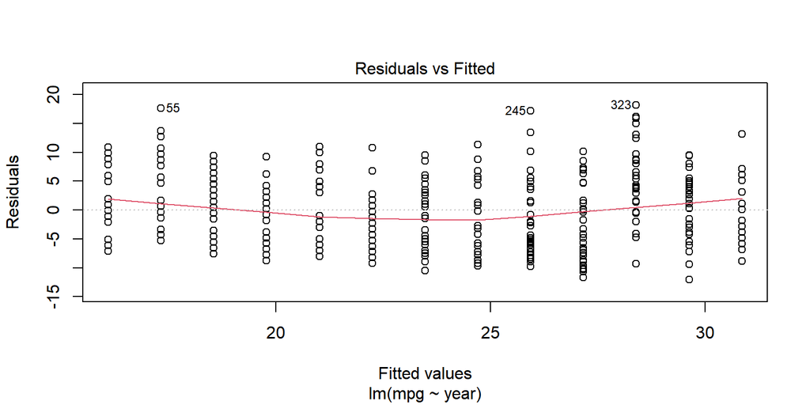

```r
plot(fit1, 1)
```

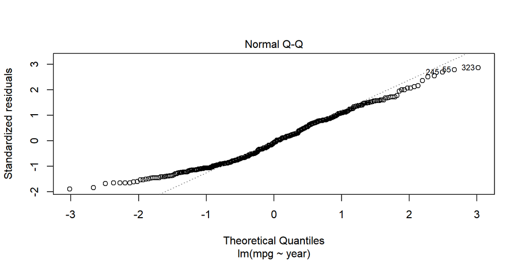

```r
plot(fit1, 2)
```

Above is result from the regression of mpg and year. The p value of year is less than 2e-16, which is far smaller than 0.05. Thus, year is a significant variable at the 0.05 level. This model indicates that if the year increases by 1, the mpg will increase by 1.23. But the R square is only 0.337 that only explain little variance. From the qq plot, we could found that the lower tails deviates that it doesn’t satisfy normal distribution.

2. Add `horsepower` on top of the variable `year` to your linear model. Is `year` still a significant variable at the .05 level? Give a precise interpretation of the `year`’s effect found here.

```r
fit2 <- lm(mpg ~ year + horsepower, data = Auto)
summary(fit2)
```

```
##
## Call:
## lm(formula = mpg ~ year + horsepower, data = Auto)
##
## Residuals:
##     Min      1Q  Median      3Q     Max
## -12.077  -3.078  -0.431   2.588  15.315
##
## Coefficients:
##              Estimate Std. Error t value Pr(>|t|)
## (Intercept) -12.73917    5.34903   -2.38    0.018 *
## year          0.65727    0.06626    9.92   <2e-16 ***
## horsepower   -0.13165    0.00634  -20.76   <2e-16 ***
## ---
## Signif. codes:  0 '***' 0.001 '**' 0.01 '*' 0.05 '.' 0.1 ' ' 1
##
## Residual standard error: 4.39 on 389 degrees of freedom
## Multiple R-squared:  0.685,  Adjusted R-squared:  0.684
## F-statistic:  424 on 2 and 389 DF,  p-value: <2e-16
```

```r
summary(fit2)$sigma
```

```
## [1] 4.39
```

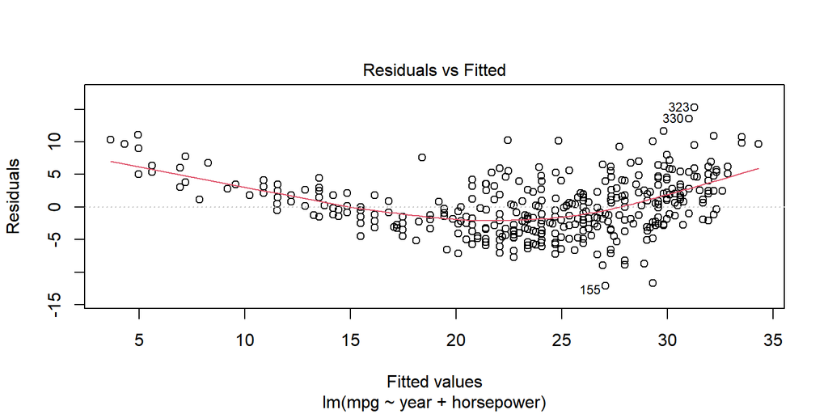

```r
plot(fit2, 1)
```

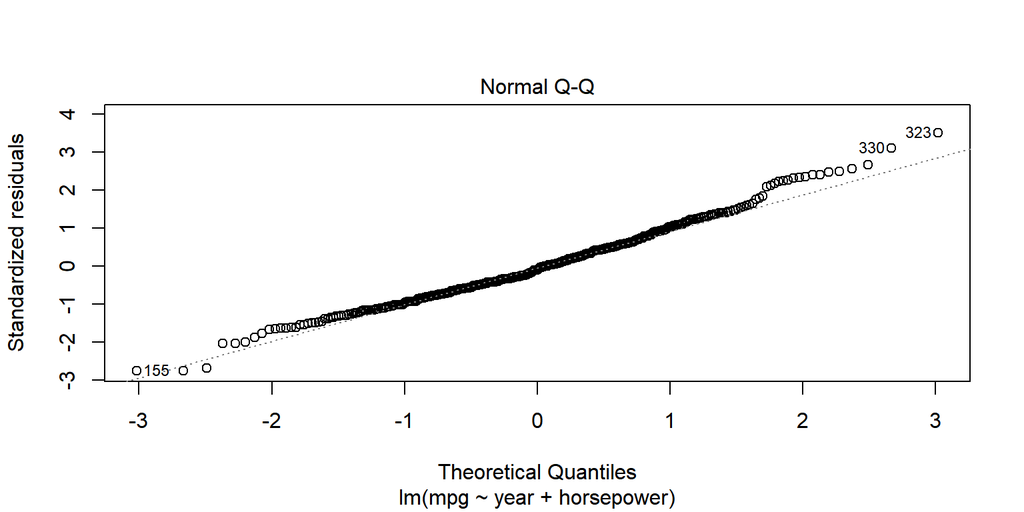

```r
plot(fit2, 2)
```

Above is result from the regression of year and horsepower on mpg. The p value of year is still less than 2e-16, which is far smaller than 0.05. Thus, year is still a significant variable at the 0.05 level. In this model, if horsepower stays the same and year increases by 1, the mpg will increase by 0.65727, which is smaller than previous model. It is because the added horsepower interpret some variance of mpg and year weights less. The R square increases from 0.337 to 0.685, which is a huge improvement. The RSE decreases from 6.36 to 4.39. The qq plot shows that the residuals roughly satisfy normal distribution.

3. The two 95% CI’s for the coefficient of year differ among (i) and (ii). How would you explain the difference to a non-statistician?

For model 1 among (i), we have [1.2300 - 1.96 * 0.0874, 1.2300 + 1.96 * 0.0874], which is [1.059, 1.4]. For model 2 among (ii), we have [0.65727 - 1.96 * 0.06626, 0.65727 + 1.96 * 0.06626], which is [0.5274, 0.787]. The addition of the variable “horsepower” in model 2 allows us to capture the effect of both year and horsepower on the dependent variable, whereas in model 1 we only capture the effect of year. This means that the coefficient of year in model 2 accounts for the effect of year on the dependent variable, controlling for the effect of horsepower. The difference in the two CIs reflects this difference in the models. Model 2 takes into account the effect of horsepower, which can affect the precision of the estimate of the coefficient of year. As a result, the CI for the coefficient of year in model 2 is narrower than the CI in model 1, which only accounts for the effect of year. This indicates that model 2 is a more precise estimate of the effect of year on the dependent variable, as it accounts for the effect of another important variable.

4. Create a model with interaction by fitting `lm(mpg ~ year * horsepower)`. Is the interaction effect significant at .05 level? Explain the year effect (if any).

```r
fit3 <- lm(mpg ~ year * horsepower, data = Auto)
summary(fit3)
```

```
##
## Call:
## lm(formula = mpg ~ year * horsepower, data = Auto)
##
## Residuals:
##     Min      1Q  Median      3Q     Max
## -12.349  -2.451  -0.456   2.406  14.444
##
## Coefficients:
##                  Estimate Std. Error t value Pr(>|t|)
## (Intercept)     -1.27e+02   1.21e+01  -10.45   <2e-16 ***
## year             2.19e+00   1.61e-01   13.59   <2e-16 ***
## horsepower       1.05e+00   1.15e-01    9.06   <2e-16 ***
## year:horsepower -1.60e-02   1.56e-03  -10.22   <2e-16 ***
## ---
## Signif. codes:  0 '***' 0.001 '**' 0.01 '*' 0.05 '.' 0.1 ' ' 1
##
## Residual standard error: 3.9 on 388 degrees of freedom
## Multiple R-squared:  0.752,  Adjusted R-squared:  0.75
## F-statistic:  393 on 3 and 388 DF,  p-value: <2e-16
```

```r
summary(fit3)$sigma
```

```
## [1] 3.9
```

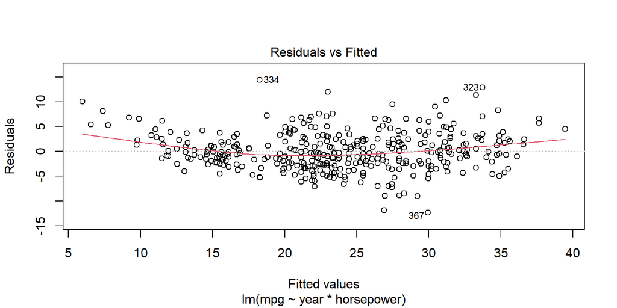

```r
plot(fit3, 1)
```

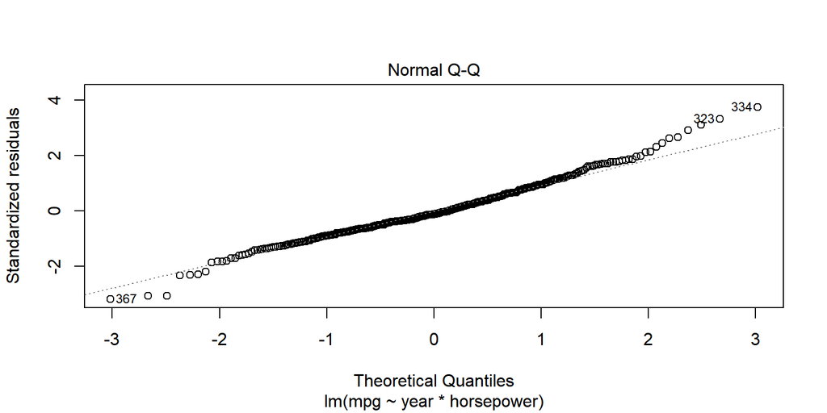

```r
plot(fit3, 2)
```

## 3.3 Categorical predictors

Remember that the same variable can play different roles! Take a quick look at the variable `cylinders`, and try to use this variable in the following analyses wisely. We all agree that a larger number of cylinders will lower mpg. However, we can interpret `cylinders` as either a continuous (numeric) variable or a categorical variable.

1. Fit a model that treats `cylinders` as a continuous/numeric variable. Is `cylinders` significant at the 0.01 level? What effect does `cylinders` play in this model?

```r
fit_num <- lm(mpg ~ cylinders, data = Auto)
summary(fit_num)
```

```
##
## Call:
## lm(formula = mpg ~ cylinders, data = Auto)
##
## Residuals:
##     Min      1Q  Median      3Q     Max
## -14.241  -3.183  -0.633   2.549  17.917
##
## Coefficients:
##             Estimate Std. Error t value Pr(>|t|)
## (Intercept)   42.916      0.835    51.4   <2e-16 ***
## cylinders     -3.558      0.146   -24.4   <2e-16 ***
## ---
## Signif. codes:  0 '***' 0.001 '**' 0.01 '*' 0.05 '.' 0.1 ' ' 1
##
## Residual standard error: 4.91 on 390 degrees of freedom
## Multiple R-squared:  0.605,  Adjusted R-squared:  0.604
## F-statistic:  597 on 1 and 390 DF,  p-value: <2e-16
```

```r
summary(fit_num)$sigma
```

```
## [1] 4.91
```

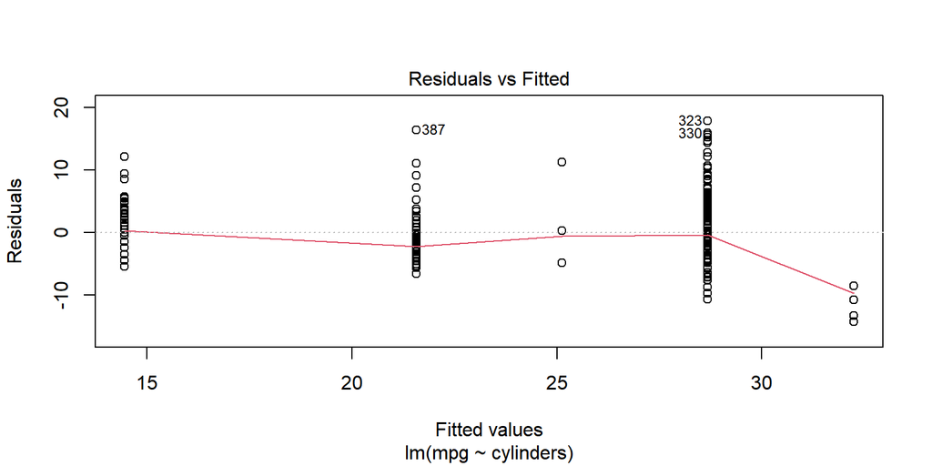

```r
plot(fit_num, 1)
```

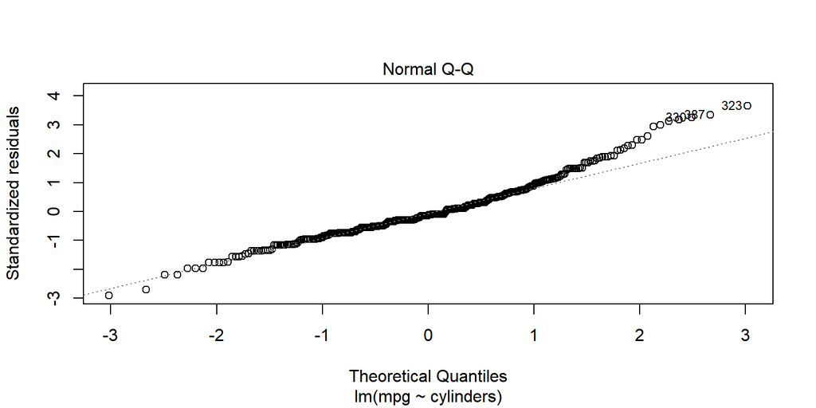

```r
plot(fit_num, 2)
```

Above is result from the regression of numeric cylinders on mpg. The p value of cylinders is still less than 2e-16, which is far smaller than 0.05. Thus, cylinders is still a significant variable at the 0.05 level. In this model, if cylinders increases by 1, the mpg will decrease by 3.558. Adding numeric cylinder, the R square is 0.605. The RSE is 4.91. The qq plot shows that the residuals roughly satisfy normal distribution except for sample 387 and 323.

2. Fit a model that treats `cylinders` as a categorical/factor. Is `cylinders` significant at the .01 level? What is the effect of `cylinders` in this model? Describe the `cylinders` effect over `mpg`.

```r
fit_factor <- lm(mpg ~ factor(cylinders), data = Auto)
summary(fit_factor)
```

```
##
## Call:
## lm(formula = mpg ~ factor(cylinders), data = Auto)
##
## Residuals:
##     Min      1Q  Median      3Q     Max
## -11.284  -2.904  -0.963   2.344  18.027
##
## Coefficients:
##                    Estimate Std. Error t value Pr(>|t|)
## (Intercept)          20.550      2.349    8.75  < 2e-16 ***
## factor(cylinders)4    8.734      2.373    3.68  0.00027 ***
## factor(cylinders)5    6.817      3.589    1.90  0.05825 .
## factor(cylinders)6   -0.577      2.405   -0.24  0.81071
## factor(cylinders)8   -5.587      2.395   -2.33  0.02015 *
## ---
## Signif. codes:  0 '***' 0.001 '**' 0.01 '*' 0.05 '.' 0.1 ' ' 1
##
## Residual standard error: 4.7 on 387 degrees of freedom
## Multiple R-squared:  0.641,  Adjusted R-squared:  0.638
## F-statistic:  173 on 4 and 387 DF,  p-value: <2e-16
```

```r
summary(fit_factor)$sigma
```

```
## [1] 4.7
```

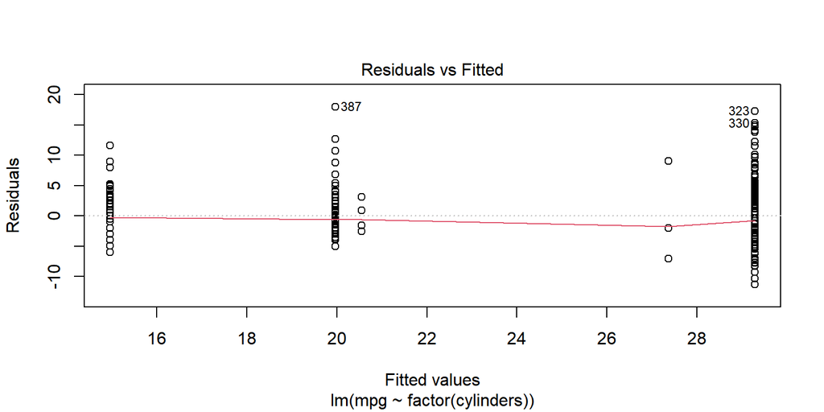

```r
plot(fit_factor, 1)
```

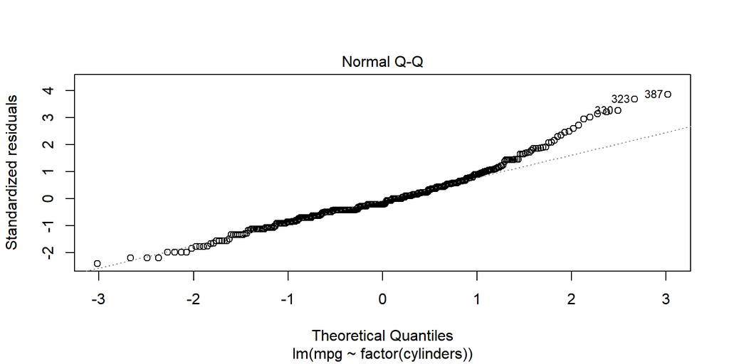

```r
plot(fit_factor, 2)
```

Above is result from the regression of factor cylinders on mpg. The p value of cylinder 3 (Intercept) is smaller than 2e-16 and cylinder 4 is 0.00027, which is smaller than 0.01. But the rest of cylinders have p value larger than 0.01. Thus, cylinders 3 and 4 is a significant variable at the 0.01 level while other cylinder are insignificant. In this model, if it is cylinder 3, then the mpg is the value of Intercept. If it is cylinder 4, then the mpg will increase from Intercept by 8.734, i.e. 8.734 mpg greater than cylinder 3. If it is cylinder 5, then the mpg will increase from Intercept by 6.817, i.e. 6.817 mpg greater than cylinder 3. If it is cylinder 6, then the mpg will decrease from Intercept by 0.577, i.e. 0.577 mpg less than cylinder 3. If it is cylinder 8, then the mpg will decrease from Intercept by 5.587, i.e. 5.587 mpg less than cylinder 3. The model has R square 0.641 and RSE 4.7.

3. What are the fundamental differences between treating `cylinders` as a continuous and categorical variable in your models?

When treating cylinders as a continuous variable, the model assumes that there is a smooth, numerical relationship between the cylinders variable and the target variable, and the goal is to fit a line or curve that best captures this relationship. This approach is usually appropriate when the variable has a natural ordering and there is a clear magnitude difference between the different values.

When treating cylinders as a categorical variable, the model instead creates separate categories for each distinct value of the variable, and the goal is to model the relationship between each category and the target variable. This approach is usually appropriate when the variable does not have a natural ordering, or there is no clear magnitude difference between the values.

4. Can you test the null hypothesis: fit0: `mpg` is linear in `cylinders` vs. fit1: `mpg` relates to `cylinders` as a categorical variable at .01 level?

```r
anova(fit_num, fit_factor)
```

```
## Analysis of Variance Table
##
## Model 1: mpg ~ cylinders
## Model 2: mpg ~ factor(cylinders)
##   Res.Df  RSS Df Sum of Sq    F  Pr(>F)
## 1    390 9416
## 2    387 8544  3       871 13.2 3.4e-08 ***
## ---
## Signif. codes:  0 '***' 0.001 '**' 0.01 '*' 0.05 '.' 0.1 ' ' 1
```

In this case, the ANOVA table shows that the p-value is less than 0.01, indicating the null hypothesis should be rejected, i.e. Model 2 is a better fit than Model 1. The factor(cylinders) term in Model 2 represents the relationship between mpg and cylinders as a categorical variable, while the cylinders term in Model 1 represents a linear relationship between mpg and cylinders. Thus, this result suggests that the relationship between mpg and cylinders is better represented as a categorical variable than as a linear variable.

## 3.4 Results

Final modeling question: we want to explore the effects of each feature as best as possible. You may explore interactions, feature transformations, higher order terms, or other strategies within reason. The model(s) should be as parsimonious (simple) as possible unless the gain in accuracy is significant from your point of view.

1. Describe the final model. Include diagnostic plots with particular focus on the model residuals and diagnoses.

```r
fit_final <- lm(mpg ~ year + horsepower + weight + displacement + factor(origin) + factor(cylinders), data = Auto)
summary(fit_final)
```

```
##
## Call:
## lm(formula = mpg ~ year + horsepower + weight + displacement +
##     factor(origin) + factor(cylinders), data = Auto)
##
## Residuals:
##    Min     1Q Median     3Q    Max
## -8.704 -1.950 -0.055  1.711 12.793
##
## Coefficients:
##                     Estimate Std. Error t value Pr(>|t|)
## (Intercept)        -2.16e+01   4.23e+00   -5.11  5.1e-07 ***
## year                7.36e-01   4.87e-02   15.11  < 2e-16 ***
## horsepower         -3.71e-02   1.07e-02   -3.46   0.0006 ***
## weight             -5.70e-03   5.53e-04  -10.29  < 2e-16 ***
## displacement        1.85e-02   7.17e-03    2.58   0.0103 *
## factor(origin)2     1.76e+00   5.51e-01    3.20   0.0015 **
## factor(origin)3     2.62e+00   5.26e-01    4.98  9.7e-07 ***
## factor(cylinders)4  6.78e+00   1.64e+00    4.14  4.2e-05 ***
## factor(cylinders)5  7.15e+00   2.50e+00    2.86   0.0045 **
## factor(cylinders)6  3.40e+00   1.81e+00    1.88   0.0613 .
## factor(cylinders)8  5.14e+00   2.10e+00    2.44   0.0150 *
## ---
## Signif. codes:  0 '***' 0.001 '**' 0.01 '*' 0.05 '.' 0.1 ' ' 1
##
## Residual standard error: 3.09 on 381 degrees of freedom
## Multiple R-squared:  0.847,  Adjusted R-squared:  0.843
## F-statistic:  211 on 10 and 381 DF,  p-value: <2e-16
```

```r
summary(fit_final)$sigma
```

```
## [1] 3.09
```

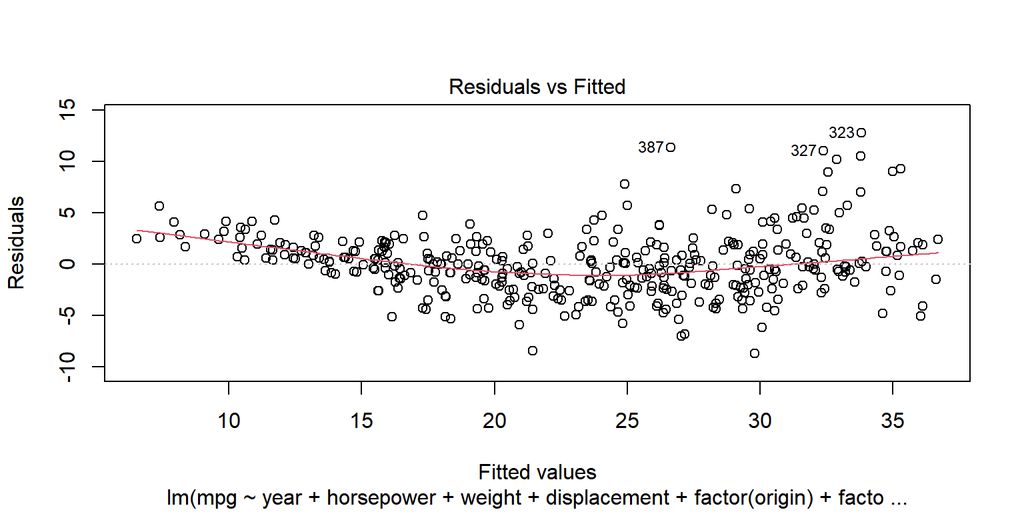

```r
plot(fit_final, 1)
```

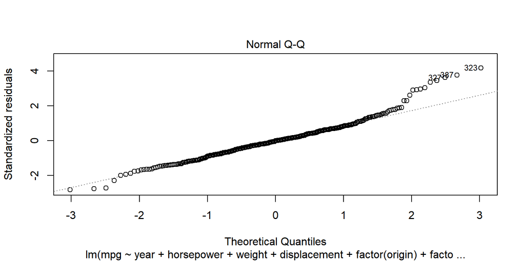

```r
plot(fit_final, 2)
```

2. Summarize the effects found.

3. Predict the `mpg` of the following car: A red car built in the US in 1983 that is 180 inches long, has eight cylinders, displaces 350 cu. inches, weighs 4000 pounds, and has a horsepower of 260. Also give a 95% CI for your prediction.

```r
new_car <- data.frame(year = 83,
                      horsepower = 260,
                      weight = 4000,
                      origin = 1,
                      cylinders = 8,
                      displacement = 350)

prediction <- predict(fit_final, newdata = new_car, interval = "confidence", level = 0.95)
prediction
```

```
##    fit  lwr  upr
## 1 18.6 16.1 21.2
```

# 4 Simple Regression through simulations

## 4.1 Linear model through simulations

This exercise is designed to help you understand the linear model using simulations. In this exercise, we will generate $(x_i, y_i)$ pairs so that all linear model assumptions are met.

Presume that $\mathbf{x}$ and $\mathbf{y}$ are linearly related with a normal error $\boldsymbol{\varepsilon}$ , such that $\mathbf{y} = 1 + 1.2\mathbf{x} + \boldsymbol{\varepsilon}$. The standard deviation of the error $\varepsilon_i$ is $\sigma = 2$.

We can create a sample input vector ($n = 40$) for $\mathbf{x}$ with the following code:

```r
# Generates a vector of size 40 with equally spaced values between 0 and 1, inclusive
x <- seq(0, 1, length = 40)
```

### 4.1.1 Generate data

Create a corresponding output vector for $\mathbf{y}$ according to the equation given above. Use `set.seed(1)`. Then, create a scatterplot with $(x_i, y_i)$ pairs. Base R plotting is acceptable, but if you can, please attempt to use `ggplot2` to create the plot. Make sure to have clear labels and sensible titles on your plots.

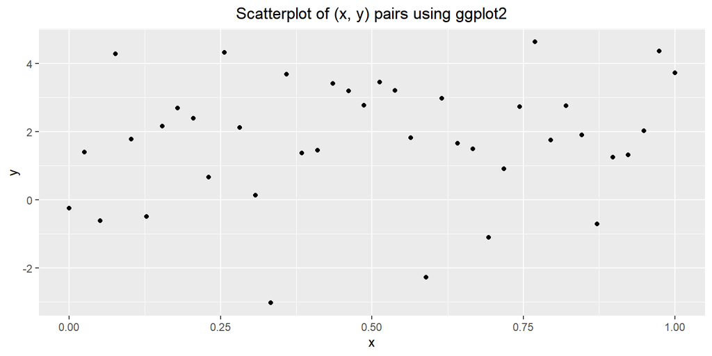

### 4.1.2 Understand the model

1. Find the LS estimates of $\boldsymbol{\beta}_0$ and $\boldsymbol{\beta}_1$, using the `lm()` function. What are the true values of $\boldsymbol{\beta}_0$ and $\boldsymbol{\beta}_1$? Do the estimates look to be good?

```
##
## Call:
## lm(formula = y ~ x)
##
## Residuals:
##    Min     1Q Median     3Q    Max
## -4.662 -0.880  0.014  1.247  2.882
##
## Coefficients:
##             Estimate Std. Error t value Pr(>|t|)
## (Intercept)    1.331      0.557    2.39    0.022 *
## x              0.906      0.959    0.95    0.350
## ---
## Signif. codes:  0 '***' 0.001 '**' 0.01 '*' 0.05 '.' 0.1 ' ' 1
##
## Residual standard error: 1.79 on 38 degrees of freedom
## Multiple R-squared:  0.023,  Adjusted R-squared:  -0.00272
## F-statistic: 0.894 on 1 and 38 DF,  p-value: 0.35
```

The true value of $\boldsymbol{\beta}_0$ is 1 and $\boldsymbol{\beta}_1$ is 1.2 while the estimate of $\boldsymbol{\beta}_0$ is 1.331 and $\boldsymbol{\beta}_1$ is 0.906. The estimate doesn’t look good.

2. What is your RSE for this linear model fit? Is it close to $\sigma = 2$?

The RSE is approximately 1.79, which is close to $\sigma = 2$

3. What is the 95% confidence interval for $\boldsymbol{\beta}_1$? Does this confidence interval capture the true $\boldsymbol{\beta}_1$?

```
##              2.5 % 97.5 %
## (Intercept)  0.203   2.46
## x           -1.034   2.85
```

The 95% confidence interval for $\boldsymbol{\beta}_1$ is [-1.034,2.85], which captures the true $\boldsymbol{\beta}_1$ 1.2.

4. Overlay the LS estimates and the true lines of the mean function onto a copy of the scatterplot you made above.

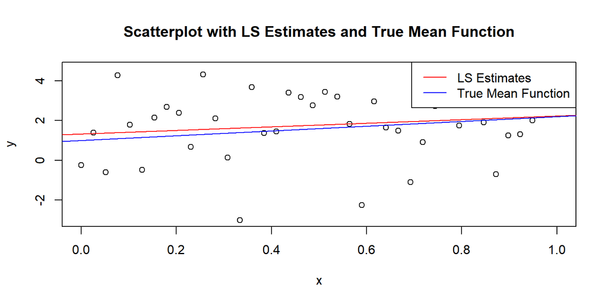

The blue line is the true line of the mean function and the red line is the LS estimate of the mean function. We could conclude that they are similar to each other.

### 4.1.3 diagnoses

1. Provide residual plot where fitted $\mathbf{y}$-values are on the x-axis and residuals are on the y-axis.

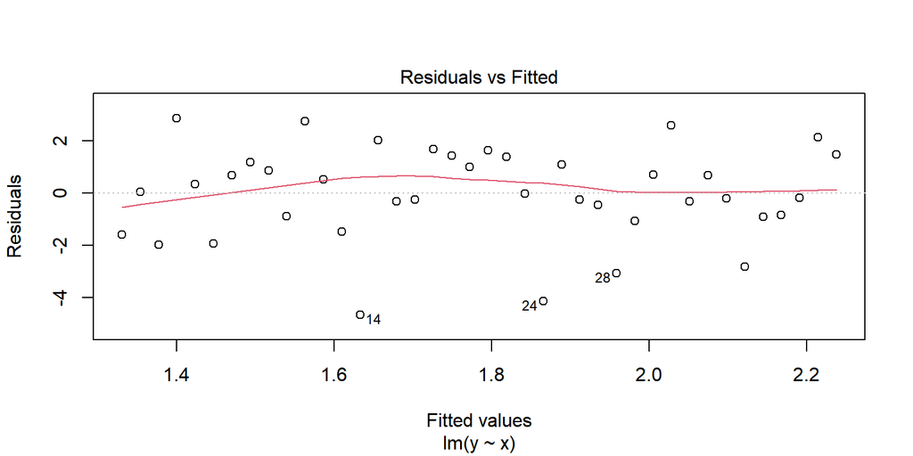

2. Provide a normal QQ plot of the residuals.

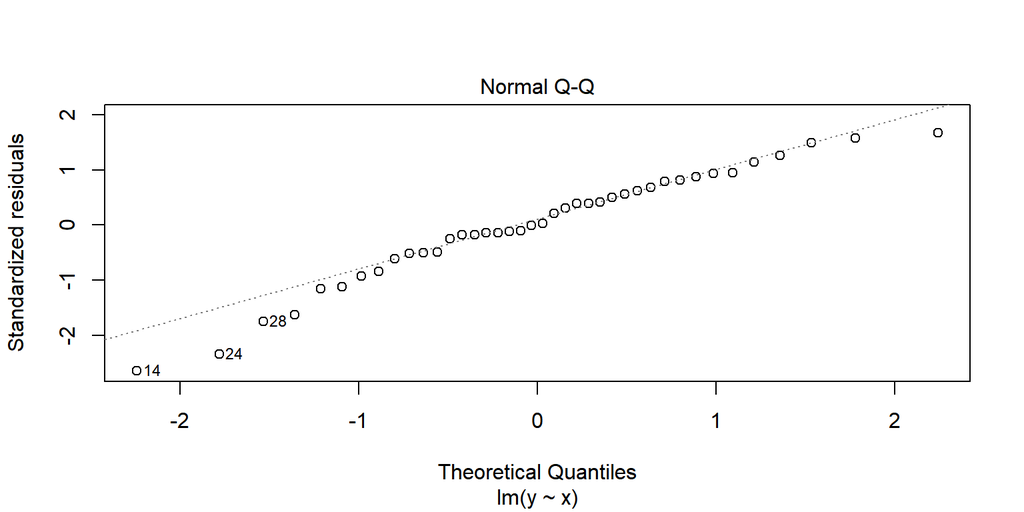

3. Comment on how well the model assumptions are met for the sample you used.

Based on the residual plot and the QQ plot, we can see that the residuals are randomly scattered around 0, and the points form a straight line in the QQ plot except for some outliers such as 28, 24, 14. This indicates that the linear model assumptions of constant variance and normality of residuals are met for the sample used.

## 4.2 Understand sampling distribution and confidence intervals

This part aims to help you understand the notion of sampling statistics and confidence intervals. Let’s concentrate on estimating the slope only.

Generate 100 samples of size $n = 40$, and estimate the slope coefficient from each sample. We include some sample code below, which should guide you in setting up the simulation. Note: this code is easier to follow but suboptimal; see the appendix for a more optimal R-like way to run this simulation.

```r
# Inializing variables. Note b_1, upper_ci, lower_ci are vectors
x <- seq(0, 1, length = 40)
n_sim <- 100              # number of simulations
b1 <- 0                   # n_sim many LS estimates of beta_1 (=1.2). Initialize to 0 for now
upper_ci <- 0             # upper bound for beta_1. Initialize to 0 for now.
lower_ci <- 0             # lower bound for beta_1. Initialize to 0 for now.
t_star <- qt(0.975, 38)   # Food for thought: why 38 instead of 40? What is t_star?

# Perform the simulation
for (i in 1:n_sim){
  y <- 1 + 1.2 * x + rnorm(40, sd = 2)
  lse <- lm(y ~ x)
  lse_output <- summary(lse)$coefficients
  se <- lse_output[2, 2]
  b1[i] <- lse_output[2, 1]
  upper_ci[i] <- b1[i] + t_star * se
  lower_ci[i] <- b1[i] - t_star * se
}
results <- as.data.frame(cbind(se, b1, upper_ci, lower_ci))
results
summary(results)
# remove unecessary variables from our workspace
# rm(se, b1, upper_ci, lower_ci, x, n_sim, b1, t_star, lse, lse_out)
```

1. Summarize the LS estimates of $\boldsymbol{\beta}_1$ (stored in `results$b1`). Does the sampling distribution agree with theory?

After summarizing the estimates of $\boldsymbol{\beta}_1$ and its confidence interval, more than 75% lower bound is smaller than 1.2 and more than 75% upper bound is larger than 1.2. Thus, we could conclude that the sampling distribution agrees with theory.

2. How many of your 95% confidence intervals capture the true $\boldsymbol{\beta}_1$? Display your confidence intervals graphically.

```r
x <- seq(0, 1, length = 40)
n_sim <- 100              # number of simulations
b1 <- 0                   # n_sim many LS estimates of beta_1 (=1.2). Initialize to 0 for now
upper_ci <- 0             # upper bound for beta_1. Initialize to 0 for now.
lower_ci <- 0             # lower bound for beta_1. Initialize to 0 for now.
t_star <- qt(0.975, 38)   # Food for thought: why 38 instead of 40? What is t_star?

# Perform the simulation
for (i in 1:n_sim){
  y <- 1 + 1.2 * x + rnorm(40, sd = 2)
  lse <- lm(y ~ x)
  lse_output <- summary(lse)$coefficients
  se <- lse_output[2, 2]
  b1[i] <- lse_output[2, 1]
  upper_ci[i] <- b1[i] + t_star * se
  lower_ci[i] <- b1[i] - t_star * se
}
results <- as.data.frame(cbind(se, b1, upper_ci, lower_ci))
summary(results)
```

```
##        se             b1           upper_ci       lower_ci
##  Min.   :1.16   Min.   :-1.36   Min.   :0.66   Min.   :-3.73
##  1st Qu.:1.16   1st Qu.: 0.23   1st Qu.:2.56   1st Qu.:-2.08
##  Median :1.16   Median : 1.05   Median :3.27   Median :-1.12
##  Mean   :1.16   Mean   : 1.06   Mean   :3.29   Mean   :-1.18
##  3rd Qu.:1.16   3rd Qu.: 1.87   3rd Qu.:4.15   3rd Qu.:-0.39
##  Max.   :1.16   Max.   : 3.97   Max.   :5.98   Max.   : 1.95
```

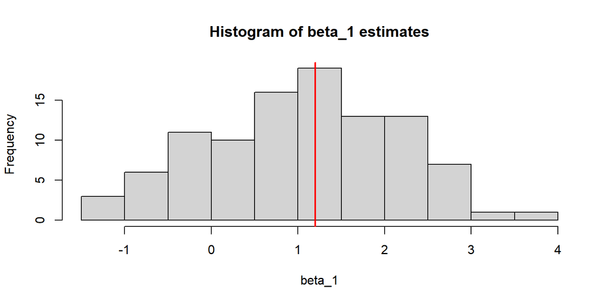

```r
hist(results$b1, main = "Histogram of beta_1 estimates", xlab = "beta_1")
abline(v = 1.2, col = "red", lwd = 2) # add vertical line at true beta_1
```

```r
# calculate the proportion of confidence intervals that capture the true beta_1
capture_proportion <- mean(results$upper_ci >= 1.2 & results$lower_ci <= 1.2)
capture_proportion
```

```
## [1] 0.96
```